# Egzaminas

Milda Zarankaite

2016 m birželis 14 d

# Praktinės Ekonometrijos II egzaminas

Instaliuojamos reikalingos bibliotekos

```r
library(car)
library(fpp)
library(dynlm)
library(knitr) #kable
library(dplyr) #trainSet 2 uŽduočiai
```

# Užduotys ir sprendimai

*Užkomentuotas ir nepanaudotas kodas - buvo template, bet arba nemokėjau padaryt arba nespėjau.

### Užduotis nr.1

Atlikta tik empyriškai.

Sukuriame X funkciją

```r
X<-function(){
  x_1<-rnorm(1, mean=3, sd=2)
  x_2<-rnorm(1, mean=-1, sd=2)
  return(x_1+x_2)
}
```

1. Rasti $X$ teorinį skirstinį

```r
#! prob - galutinės tikimybes
```

2. Sugeneruokite $X$ imtį ($N=10000$) pagal pateiktą $X$ apibrėžimą.

```r
eksper_b<-replicate(10000, X())
```

3. Palyginkite sugeneruotą $X$ empirinį skirstinį su teorinį skirstiniu.  
   Palyginimui pateikite tankių grafikus ir skirstinių charakteristikas (vidurkį, medianą ir standartinį nuokrypį)

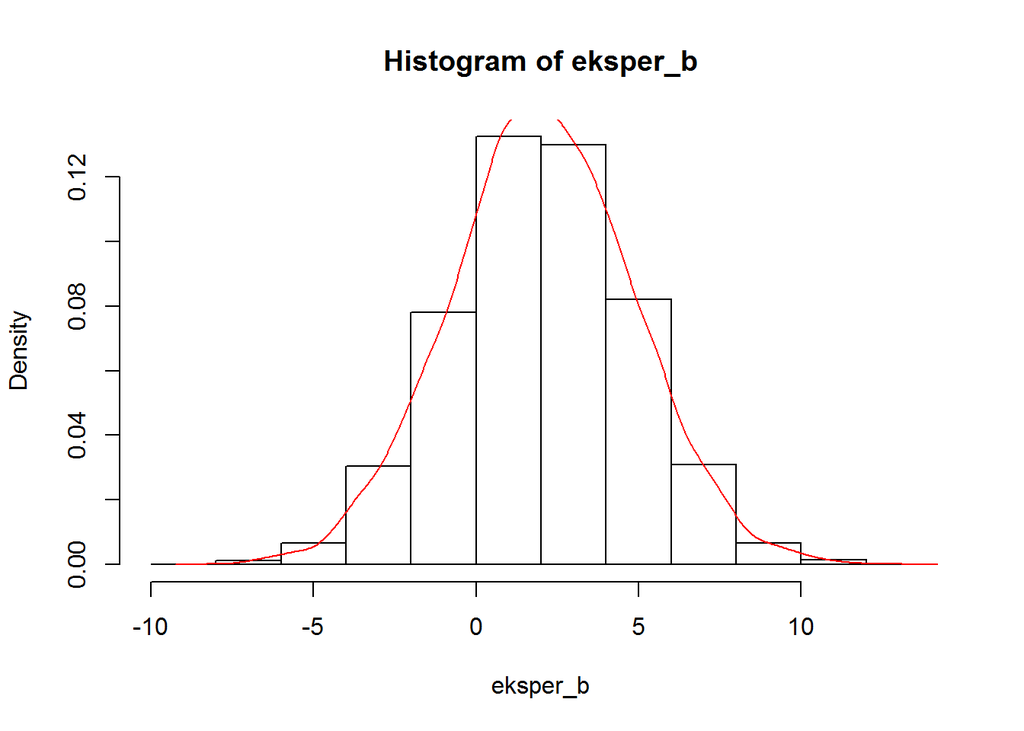

```r
#Tankių grafikai
hist(eksper_b, probability = T)
lines(density(eksper_b) , col="red")
```

```r
#Charakteristikos
mean(eksper_b)
```

```
## [1] 2.029423
```

```r
median(eksper_b)
```

```
## [1] 2.016786
```

```r
sd(eksper_b)
```

```
## [1] 2.824764
```

```r
#Lentelė
#pa<-c("Teorinis", "Empyrinis")
#vid<-c(mean(prob), mean(tik_emp))
#med<-c(median(prob), mean(tik_emp))
#sd<-c(sd(prob), sd(tik_emp))
#table1<-data.frame(pa,vid,med,sd)
#colnames(table1)<-c("Skirstinys","Vidurkis","Mediana","Standartinis nuokrypis")
#table1
```

IŠVADOS:  
1) Pagal tankio grafiką matome, kad skirstinys- normalusis, nes tankis yra varpo formos. 2) Vidurkis, mediana is standartinis nuokrypis empyrinio skirstinio pateikti iš kodo.

```r
ivykis<-function(){
  X()^2
  X()
  if((X())^2-X()-2){
    return(1)
  }
  else {
    return(0)
  }
}

#Monte Carlo:
eksp_d<-replicate(1000, ivykis())
mean(eksp_d)
```

```
## [1] 1
```

```r
#Teoriškai:
```

Monte Carlo metodu, įvykio tikimybė arti 1.

```r
ivykis_2<-function(){
  X()>0
  if((X())^2-X()-2){
    return(1)
  }
  else {
    return(0)
  }
}

#Monte Carlo:
eksp_e<-replicate(1000, ivykis_2())
mean(eksp_e)
```

```
## [1] 1
```

Monte Carlo metodu, įvykio tikimybė vėl arti 1.

### Užduotis nr2

#### 1 Duomenų apžvalga ir paruošimas

1. Nuskaitomas duomenų masyvas:

```r
datafull<-read.csv2("data_b2.csv", header = TRUE)
head(datafull)
```

```
##    islaidosVaisiams  butinosIslaidos          pajamos rajonoId
## 1  0.55264716607673  14.083383988741 27.1976217672389        2
## 2 0.352043570132186 13.3340536630728 9.23356048254358        1
## 3  0.41054439096652   5.444672968536 9.32350585248842        1
## 4 0.609335946811592 13.4877843946138 30.3525419571229        1
## 5 0.620213786386003 13.9682753211176 30.6464386758047        2
## 6 0.390109892744539 11.7340601203773  12.107559010339        3
##   atstumasIkiParduotuves
## 1       1464.66699771618
## 2       1610.16704945958
## 3       1553.04420636911
## 4       1391.91687372238
## 5       1335.35514006074
## 6       860.981545754901
```

Įkelti duomenys yra be paskutinių eilučių, kur yra duomenų paaiškinimai (ištryniau iš pačio dokumento)

2. Tvarkomi duomenys:

```r
#Šalinamos eilutės, kuriose yra trūkstamos values
datafull[datafull=="NAN"]<-NA
data2<-na.omit(datafull) #pašalintos 5 eilutės

#Nustatinėjamos klasės
str(data2)
```

```
## 'data.frame':    410 obs. of  5 variables:
##  $ islaidosVaisiams      : Factor w/ 414 levels "0.0310387203605819",..: 263 111 155 314 323 138 26 212 177 110 ...
##  $ butinosIslaidos       : Factor w/ 415 levels "10.0001111842212",..: 181 152 291 159 178 81 335 77 63 139 ...
##  $ pajamos               : Factor w/ 415 levels "10.0319685967662",..: 168 400 401 211 215 35 319 129 381 1 ...
##  $ rajonoId              : Factor w/ 4 levels "1","2","3","NAN": 2 1 1 1 2 3 2 1 3 2 ...
##  $ atstumasIkiParduotuves: Factor w/ 415 levels "1014.62131670009",..: 122 217 181 75 53 404 230 359 154 90 ...
##  - attr(*, "na.action")=Class 'omit'  Named int [1:5] 9 57 97 154 301
##   .. ..- attr(*, "names")= chr [1:5] "9" "57" "97" "154" ...
```

```r
#Pakeičiamos klasės
a<-as.numeric(as.character(data2[,1]))
b<-as.numeric(as.character(data2[,2]))
c<-as.numeric(as.character(data2[,3]))
d<-as.numeric(as.character(data2[,4]))
e<-as.numeric(as.character(data2[,5]))
data3<-data.frame(a,b,c,d,e)
colnames(data3)<-c("islaidosVaisiams","butinosIslaidos","pajamos","rajonoId","atstumas")
str(data3)
```

```
## 'data.frame':    410 obs. of  5 variables:
##  $ islaidosVaisiams: num  0.553 0.352 0.411 0.609 0.62 ...
##  $ butinosIslaidos : num  14.08 13.33 5.44 13.49 13.97 ...
##  $ pajamos         : num  27.2 9.23 9.32 30.35 30.65 ...
##  $ rajonoId        : num  2 1 1 1 2 3 2 1 3 2 ...
##  $ atstumas        : num  1465 1610 1553 1392 1335 ...
```

- Tikrinamos išskirtys:

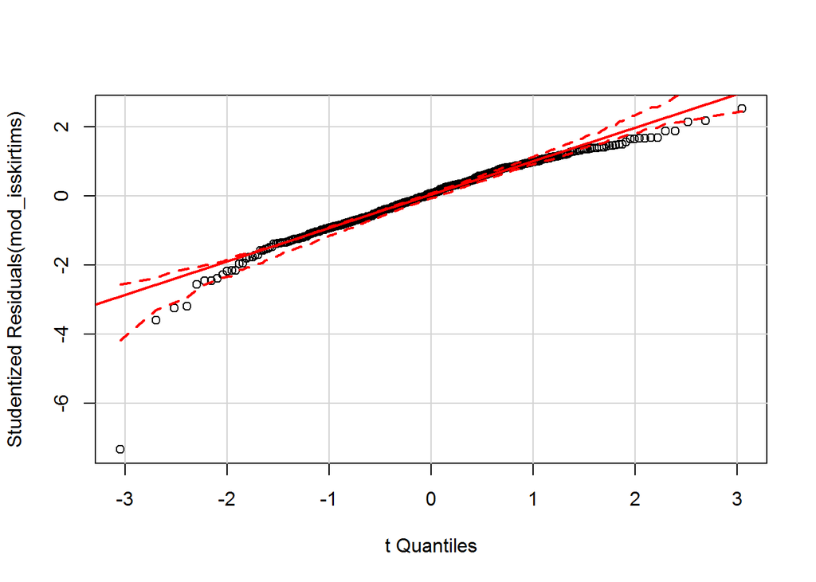

```r
mod_isskirtims<-lm(islaidosVaisiams~butinosIslaidos+pajamos+rajonoId+atstumas , data3)
qqPlot(mod_isskirtims)
```

```r
outlierTest(mod_isskirtims)
```

```
##      rstudent unadjusted p-value Bonferonni p
## 367 -7.334133         1.2311e-12   5.0477e-10
```

Rasta išskirtins 367 eilutėje, ją ištriname ir turime galutinius duomenyis, paruoštus analizei:

```r
data<-data3[-367,]
```

Duomenyse lieka 409 reikšmingų duomenų eilutės.

3. Trumpa kintamųjų apžvalga:

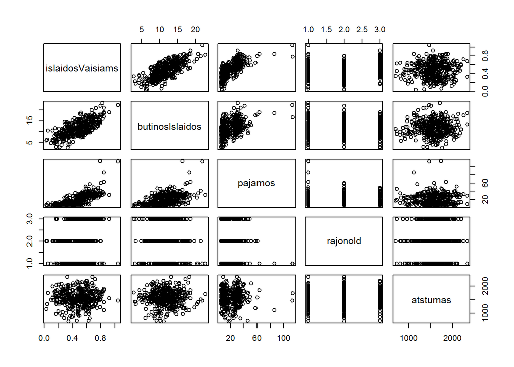

```r
plot(data)
```

```r
summary(data)
```

```
##  islaidosVaisiams  butinosIslaidos     pajamos           rajonoId
##  Min.   :0.03104   Min.   : 2.770   Min.   :  5.157   Min.   :1.000
##  1st Qu.:0.34469   1st Qu.: 9.263   1st Qu.:  9.581   1st Qu.:1.000
##  Median :0.48921   Median :11.561   Median : 17.590   Median :2.000
##  Mean   :0.47780   Mean   :11.652   Mean   : 20.813   Mean   :1.976
##  3rd Qu.:0.60394   3rd Qu.:13.865   3rd Qu.: 29.722   3rd Qu.:3.000
##  Max.   :1.04549   Max.   :22.843   Max.   :113.869   Max.   :3.000
##     atstumas
##  Min.   : 700
##  1st Qu.:1410
##  Median :1577
##  Mean   :1571
##  3rd Qu.:1763
##  Max.   :2339
```

```r
cor(data)
```

```
##                  islaidosVaisiams butinosIslaidos     pajamos    rajonoId
## islaidosVaisiams       1.00000000      0.72778352  0.74346979  0.15506168
## butinosIslaidos        0.72778352      1.00000000  0.47998445 -0.05795921
## pajamos                0.74346979      0.47998445  1.00000000 -0.07688977
## rajonoId               0.15506168     -0.05795921 -0.07688977  1.00000000
## atstumas               0.03676264      0.02571584  0.01705033  0.03733958
##                    atstumas
## islaidosVaisiams 0.03676264
## butinosIslaidos  0.02571584
## pajamos          0.01705033
## rajonoId         0.03733958
## atstumas         1.00000000
```

`plot`funkcija sufleruoja, kad rajono iD - žyminis kintamasis, o tarp kintamųjjų “islaidosVaisiams” ir butinosIslaidos galima tiesinė koreliacija. `summary`parodo, kad lyginant kintamųjų vidurkį ir jų Min. Max. Atrodo, kad pajamos gali turėti išskirčių, nes Max gerokai nutolęs nuo medianos ir vidurkio (Mean=20.8, o Max=113,86) `cor` parodo, kad kintamieji tiesiškai koreliuoti. ielaidosVaisiams ir butinosIslaidos, koreliacija yr 0,72, kas patvirtina `plot` funkcijos sufleruojam1 prielaidą apie tiesinę priklausomybę. Čia problemos nėra, nes koreliacija tarp priklausomojo ir nepriklausomojo kintamųjų.

4. Duomenų masyvo skaldymas į `trainSet` ir `testSet`. Atskyrimas naudojamas iš [čia](http://stackoverflow.com/questions/17200114/how-to-split-data-into-training-testing-sets-using-sample-function-in-r-program)

```r
trainSet<-sample_frac(data, 0.8)
am<-as.numeric(rownames(trainSet)) # because rownames() returns character
testSet<-data[-am,]
```

#### 2 Tiesinio modelio sudarymas. Modelio sudarymui naudokite `trainSet` masyvą.

1. Tiesinis modelis:

```r
mod11<-lm(islaidosVaisiams~butinosIslaidos+pajamos+rajonoId+atstumas, trainSet)
```

2. Kintamųjų reikšmingumo nustatymas:

```r
kable(summary(mod11)$coef,digits=2)
```

[output not shown]

```r
mod1<-update(mod11, islaidosVaisiams~butinosIslaidos+pajamos+rajonoId)
kable(summary(mod1)$coef,digits=2)
```

[output not shown]

3. Vertinamas modelio gerumas:
- Multikolinearumo tikrinimas naudojant Variance Inflation Factor:

```r
vif(mod1)
```

```
## butinosIslaidos         pajamos        rajonoId
##        1.353851        1.357498        1.003160
```

Multikolinearumo problemos nėra. Taip teigiama, nes egzistuojančią vidinę koreliaciją parodo koeficientai, kurių reikšmė yra daugiau nei 10 (VIF sąlyga).

*Homoskedastiškumo tikrinimas  
Išbrėžiamos sukurto modelio paklaidos:

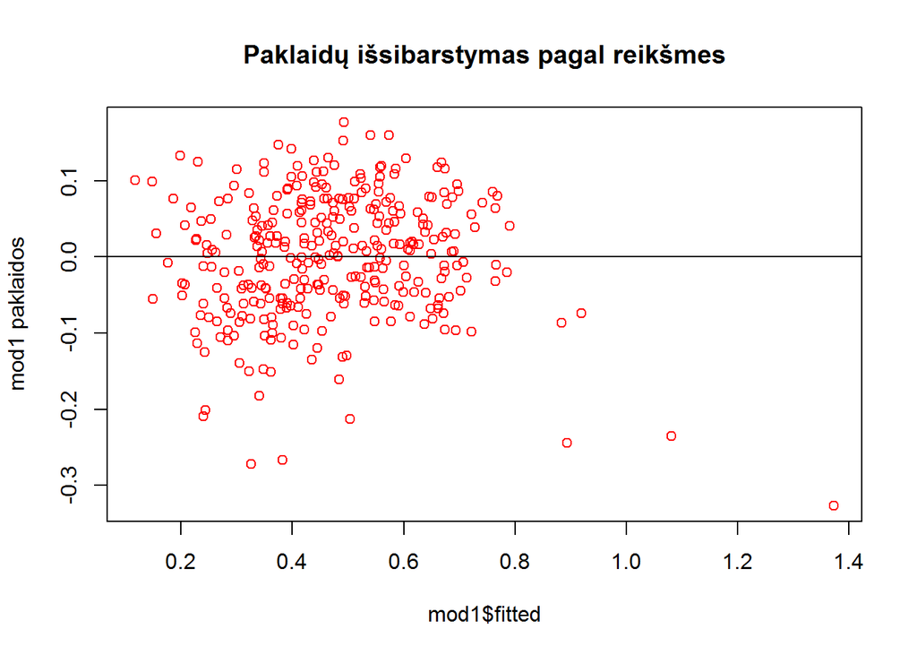

```r
par(mfrow=c(1,1))
plot(mod1$res~mod1$fitted, main="Paklaidų išsibarstymas pagal reikšmes", col=2, ylab="mod1 paklaidos")
abline(0,0)
```

Kaip matome, paklaidos pasiskirsčiusios pagal vidurkį 0, daugiausia intervale (-0.3, 0.2). Todėl spėjama, kad modelis - homoskedastiškas. Tai dar tikrinama pagal Breuch-Pagan testą (`ncvTest`)

```r
ncvTest(mod1)
```

```
## Non-constant Variance Score Test
## Variance formula: ~ fitted.values
## Chisquare = 11.5316    Df = 1     p = 0.0006842306
```

Nors pagal grafiką atrodo gerai, BET kadangi p<0.05, vadinasi, atmetame testo H0 hipotezę, kuri teigia, kad modelis homoskedastiškas - visų stebėjimų paklaidų dispersija yra konstanta. (Nežinau kodėl taip nesutampa).

“* Jei homoskedastiškumas nėra tenkinamas, tai formaliai didelės blogybės nėra - įverčiai ir toliau liktų nepaslinkti ir suderinti. Visgi reiktų būti atidiem ir papildomai pasvarstyti tris svarbius niuansus: a. Nehomogeniškumas gali indikuoti modelio neadekvatumą. Pvz. gal liko nepastebėta netiesinė sąveiką? O gal liko didelių išskirčių? b. Statistinio reikšmingumo tikrinimui naudojama kovariacijų matrica gali būti neteisinga. c. Nors įverčiai nepaslinkti, bet dabar negalime teigti, kad jie yra efektyvūs - tokiu atveju gali būti ir geresnių vertinimo būdų.” [Blogo įrašas](http://ekonometrija.lt/blog/tiesin%C4%97-regresija)

- Tikrinamas paklaidų normalumas:

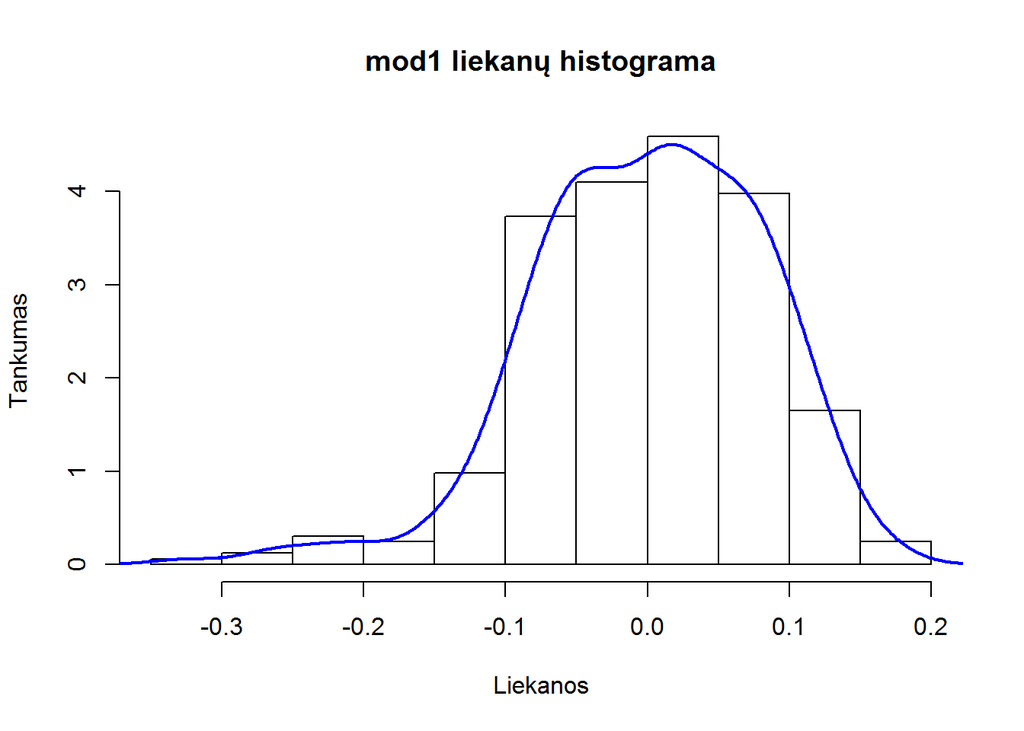

```r
histmod1<-hist(mod1$res, probability=TRUE, main="mod1 liekanų histograma", ylab="Tankumas", xlab="Liekanos")
lines(density(mod1$res), col=4, lwd=2) #liekanų tankio grafikas
```

Mėlyna linija šioje histogramoje parodo liekanų tankio pasiskirstymą. (Ji primena varpo formą, tad spėjama, kad liekanos pasiskirsčiusios normaliai.) Prielaida dar tikrinama Shapiro testu:

```r
shapiro.test(mod1$res)
```

```
##
##  Shapiro-Wilk normality test
##
## data:  mod1$res
## W = 0.9744, p-value = 1.444e-05
```

Pagal `shapiro.test` p-value<0.05 atmetame H0: liekanų paklaidos yra nėra normalios. (Vėl kažkas čia negerai?)

- Liekanų normalumą svarbu patikrinti tam, kad nustatytume, ar iš duomenų ištraukta visa naudinga informacija ir panaudota modelyje. Pavyzdžiui, ar atrasta duomenų tendencija įvertinta modelyje. Jeigu atsakymas teigiamas, paklaidos yra baltasis triukšmas (išsidėsčiusios nepriklausomai ir jų vidurkis yra 0):

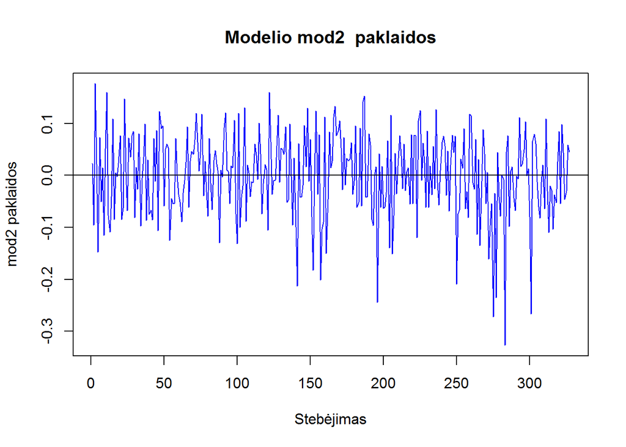

```r
plot(residuals(mod1), type="l", main="Modelio mod2  paklaidos", ylab="mod2 paklaidos", xlab="Stebėjimas", col=100)
abline(0,0)
```

Jeigu sąlyga netenkinama - modelis dar nėra pakankamai “geras”, tad verta pasvarstyti jo tobulinimą. Tačiau iš grafiko panaš, kad liekanos - baltasis triukšmas.

Išvada - pagal grafikos, atrodo, kad tenkinami modelio kokybės reikalavimai, bet testai sako ką kita.

#### 3. Modelio tobulinimas

1. Pateikiamos 2 sklaidos diagramos:

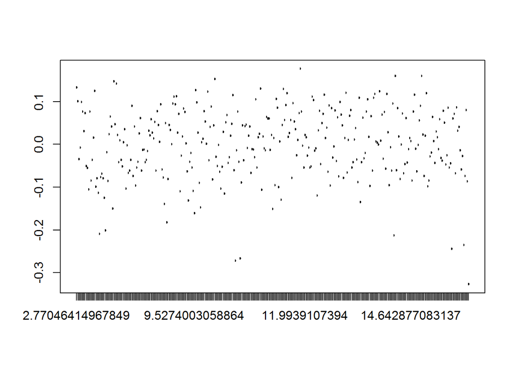

```r
boxplot(residuals(mod1)~trainSet$butinosIslaidos) #duomenys visiškai išsibarstę
```

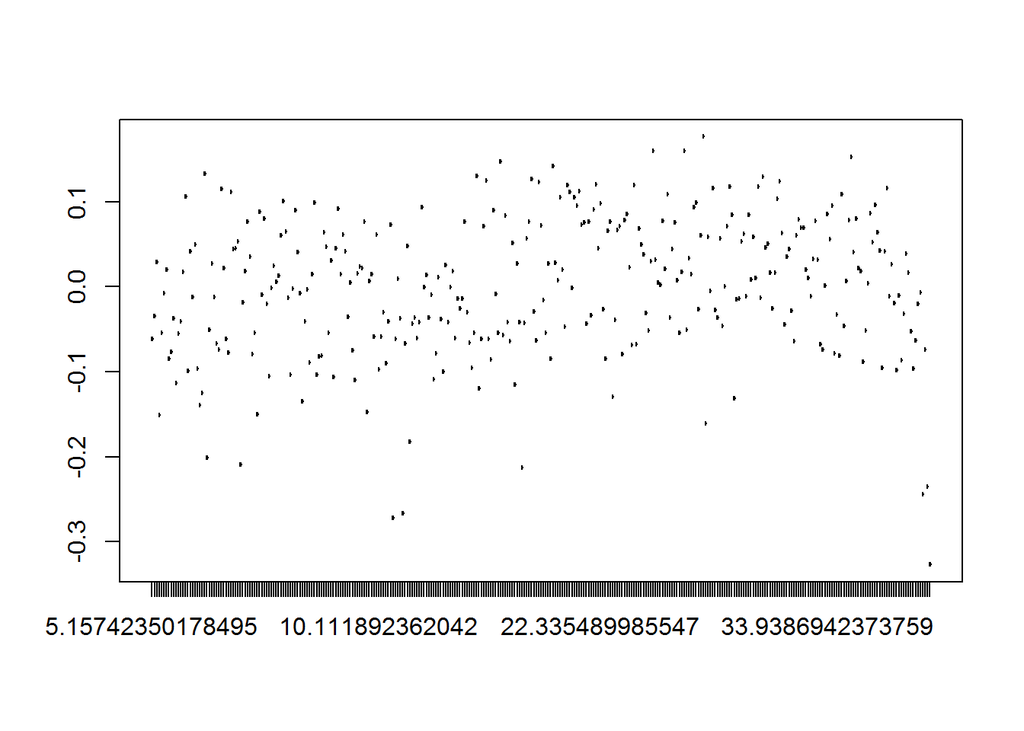

```r
boxplot(residuals(mod1)~trainSet$pajamos)#duomenys taip pat viškai išsibarstę
```

2. Siūlomi pakeitimai:  
   Aš pirmiausia atkreipčiau dėmesį į rajonoId, kuris galimai yra žyminis kintamasis:

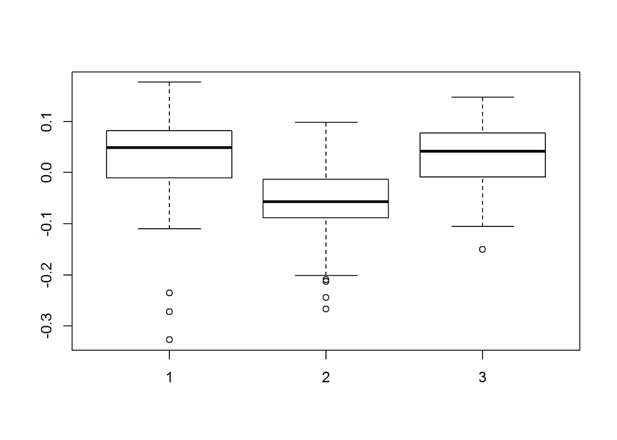

```r
boxplot(residuals(mod1)~trainSet$rajonoId)
```

```r
rajon<-as.factor(trainSet$rajonoId)
fit2<-lm(islaidosVaisiams~butinosIslaidos+pajamos+rajon, trainSet)
kable(summary(fit2)$coef,digits=2)
```

[output not shown]

#### 4. Modelių palyginimas ir prognozė.

1. Suskaičiuokite modelių `fit1` ir `fit2` MSE pagal pateiktą formulę ir patalpiname lentelėje.

```r
fit1<-mod1 #pervadinu, nes visur kitur naudojau mod1
mse1<-(1/length(trainSet$islaidosVaisiams)*(sum(residuals(fit1))^2))
mod1test<-lm(islaidosVaisiams ~ butinosIslaidos + pajamos, data = testSet)
mse11<-(1/length(testSet$islaidosVaisiams)*(sum(residuals(mod1test))^2))
mse2<-(1/length(trainSet$islaidosVaisiams)*(sum(residuals(fit2))^2))
rajon1<-as.factor(testSet$rajonoId)
mod2test<-lm(islaidosVaisiams ~ butinosIslaidos + pajamos + rajon1, data=testSet)
mse21<-(1/length(testSet$islaidosVaisiams)*(sum(residuals(mod2test))^2))

pav<-c("Training set", "Test set")
mse_fit1<-c(mse1,mse11)
mse_fit2<-c(mse2,mse21)
tab2<-data.frame(pav,mse_fit1,mse_fit2)
colnames(tab2)<-c(" ","fit1","fit2")
tab2
```

```
##                        fit1         fit2
## 1 Training set 9.571328e-36 1.276925e-35
## 2     Test set 1.450248e-37 8.705116e-35
```

```r
aic<-c(AIC(fit1), AIC(fit2))
r.sq<-c(summary(fit1)$r.squared, (summary(fit2))$r.squared)
pav<-c("fit1", "fit2")
tab3<-data.frame(pav,aic,r.sq)
tab3
```

```
##    pav       aic      r.sq
## 1 fit1 -709.0116 0.8017653
## 2 fit2 -822.2363 0.8606369
```

```r
fitMain<-fit2
fitMain
```

```
##
## Call:
## lm(formula = islaidosVaisiams ~ butinosIslaidos + pajamos + rajon,
##     data = trainSet)
##
## Coefficients:
##     (Intercept)  butinosIslaidos          pajamos           rajon2
##         0.02526          0.02397          0.00755         -0.04097
##          rajon3
##         0.10247
```

*Vėl tikrinau `fitMain` pagal testus, kurių neatitiko mod1 - išvados tokios pačios.

### Užduotis nr3

Naudojami `M1Germany` duomenys

```r
head(M1Germany)
```

```
##            logm1 logprice   loggnp interest
## 1960 Q1 7.947090 3.403827 8.309448    0.062
## 1960 Q2 7.996191 3.380212 8.387236    0.064
## 1960 Q3 7.949908 3.436211 8.465361    0.064
## 1960 Q4 8.030746 3.419888 8.477333    0.062
## 1961 Q1 7.951792 3.449861 8.374404    0.060
## 1961 Q2 8.020040 3.427157 8.420854    0.057
```

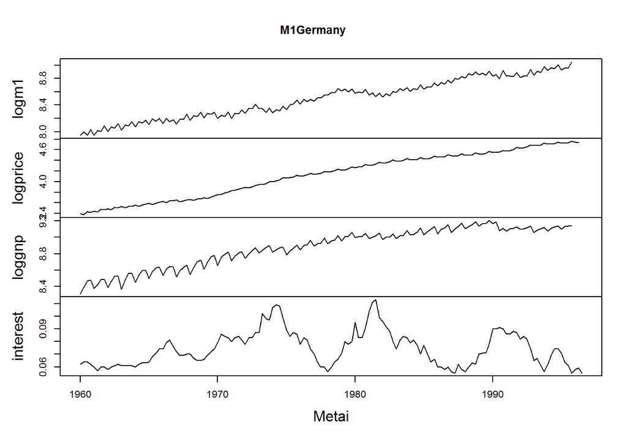

```r
plot(M1Germany, xlab="Metai")
```

Matomas duomenų didėjantis trendas.

#### 1)

1. Įvertinti tiesinę regresiją pateikto modelio.

Užduotį susiprastinu iki mod_3a, nes nepavyko išsitraukti seasonal komponentės ir padaryt (t-2) skirtumo $\Delta$

```r
#data_3<-as.ts(M1Germany)
#stl(data_3)
#stl_data<-stl(data_3, s.window = "periodic")
#data_s<-stl_data$time.series[,"seasonal"]

mod_3a<-dynlm(logprice~L(loggnp,1)+L(loggnp,2),data=M1Germany )
summary(mod_3a)
```

```
##
## Time series regression with "zooreg" data:
## Start = 1960 Q3, End = 1996 Q1
##
## Call:
## dynlm(formula = logprice ~ L(loggnp, 1) + L(loggnp, 2), data = M1Germany)
##
## Residuals:
##      Min       1Q   Median       3Q      Max
## -0.19156 -0.07208 -0.01903  0.05781  0.22898
##
## Coefficients:
##              Estimate Std. Error t value Pr(>|t|)
## (Intercept)  -11.0742     0.3102 -35.701  < 2e-16 ***
## L(loggnp, 1)   0.9406     0.1464   6.426 1.92e-09 ***
## L(loggnp, 2)   0.7718     0.1440   5.359 3.37e-07 ***
## ---
## Signif. codes:  0 '***' 0.001 '**' 0.01 '*' 0.05 '.' 0.1 ' ' 1
##
## Residual standard error: 0.0974 on 140 degrees of freedom
## Multiple R-squared:  0.9452, Adjusted R-squared:  0.9444
## F-statistic:  1207 on 2 and 140 DF,  p-value: < 2.2e-16
```

2. Gautos lygties liekanos:

```r
ser<-as.ts(residuals(mod_3a))
```

3. Eilutės stacionarumas.  
   Išbrėžiamas grafikas:

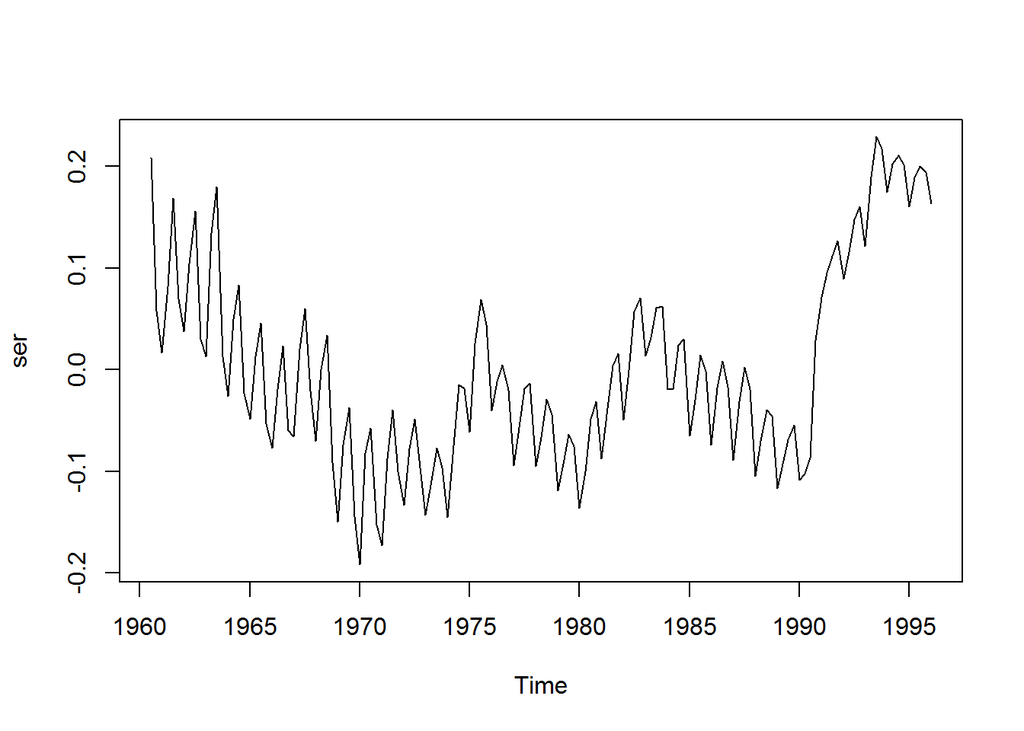

```r
plot(ser)
```

Nepanašu, kad eilutė būtų stacionari, nes duomenys turi ciklus, negalima nustatyti vidurkio.  
Tiktinama pagal Kwiatkowski-Phillips-Schmidt-Shin (KPSS) testą, kur H0: duomenys yra stacionarūs ir nesezoniniai, bei duomenų grafiką:

```r
kpss.test(ser)
```

```
##
##  KPSS Test for Level Stationarity
##
## data:  ser
## KPSS Level = 1.0098, Truncation lag parameter = 2, p-value = 0.01
```

Kadangi testo p-value<0.05, H0 - atmetame, duomenys - nėra stacionarūs ir nesezoniniai.

Kadanti H0 atmetame, ieškoma tinkamos skirtumų operacijos:

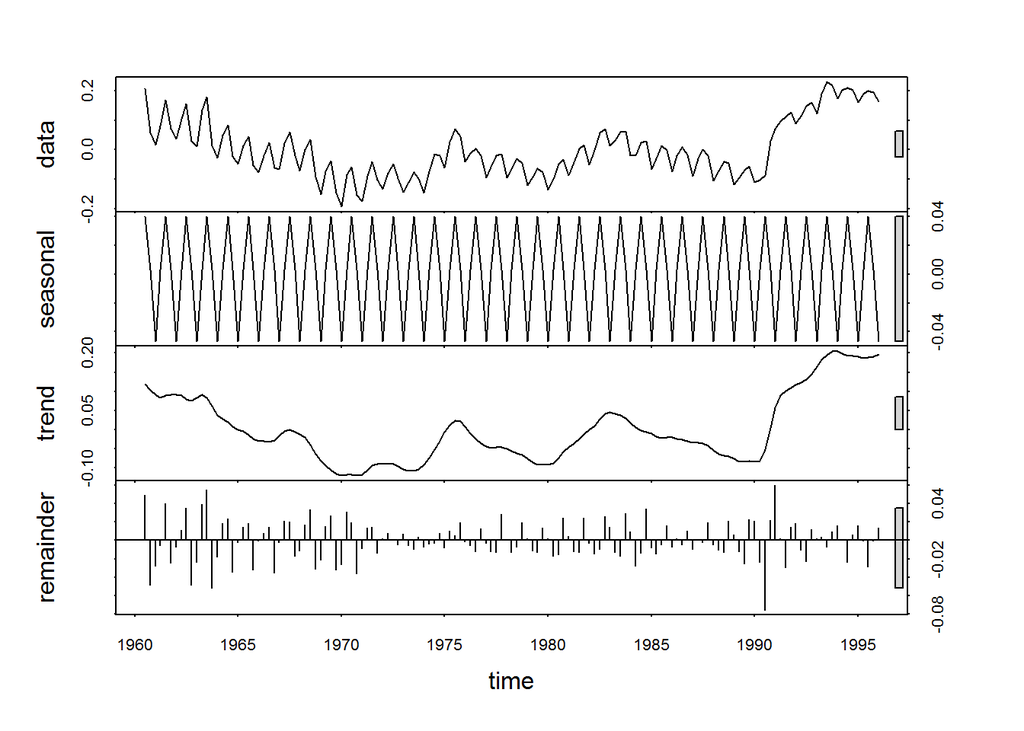

```r
plot(stl(ser, s.window="periodic"))
```

Lygindami ir atsižvelgdami į pirmą ir antrą grafikus, darome išvadą, kad duomenys galėtų būti sezoniški. Tačiau bandyta taikyti“nsdiff” ir rezultate buvo 0, tad taikysime ndiff:

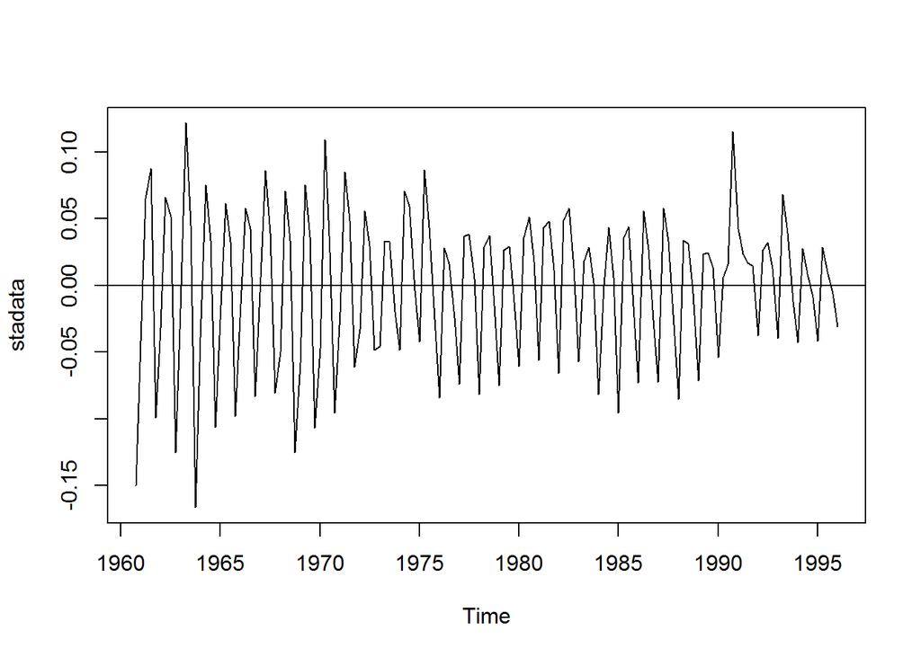

```r
dif <- ndiffs(ser) #įrašomas reikalingas skirtumų skaičius
stadata<-diff(ser,lag=frequency(4), differences=dif) #išsaugoma stationarūs duomenys
plot(stadata)
abline(0,0)
```

```r
kpss.test(stadata)
```

```
##
##  KPSS Test for Level Stationarity
##
## data:  stadata
## KPSS Level = 0.1961, Truncation lag parameter = 2, p-value = 0.1
```

Kadangi testo p-value>0.05, H0 - priimame, duomenys “stadata” - stacionarūs ir nesezoniniai.  
Taip pat iš grafiko matome, kad duomeny atrodo stacionarūs ir yra išsidėstę apie 0 vidurkį.

5. Box-Cox transformacija:  
   Duomenims ši transformacija nėra būtina, nes panašu, kad svyravimai yra tolydūs.Tikriname (reikia surasti ir lambda, tam kad įvykdytume tinkamą transformaciją). Po to, išbrėžiame ją su originaliais duomenimis.

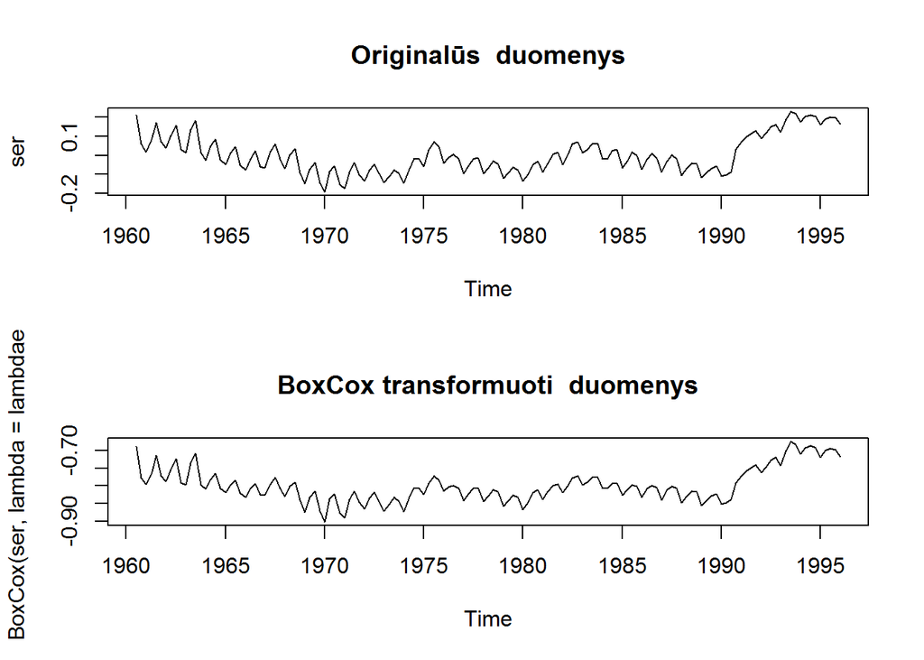

```r
lambdae<-BoxCox.lambda(ser)
par(mfcol=c(2,1))
plot(ser , main="Originalūs  duomenys")
plot(BoxCox( ser, lambda=lambdae), main="BoxCox transformuoti  duomenys")
```

Iš grafiko matome, kad pagal Box-Cox metodą, duomenys tapo tik truputėli labiau reguliariais, sezoniškumo svyravimai pasidarė nežymiai tolygesni. Tad, kadangi esminių skirtumų nelabai yra, lieku prie originalių duomenų.

#### 2

*Modelį vadinsiu `mod_1`, nes `mod1`, jau uŽimtas antroje užduotyje. a) `ets` funkcija raskite siūlomą eksponentinio glodinimo modelį:

```r
mod_1<-ets(ser)
mod_1[13]
```

```
## $method
## [1] "ETS(A,N,A)"
```

A- addictive errors, N- no trend, A - additive season.

```r
mod_b1<-ets(ser, model="AAA")
mod_b2<-ets(ser, model="ANN")
#Tikriname kuris geresnis prieš pasirinkdami
#AIC
AIC(mod_b1)
```

```
## [1] -319.5694
```

```r
AIC(mod_b2)
```

```
## [1] -122.9413
```

```r
#accuracy
accuracy(mod_b1)
```

```
##                       ME       RMSE        MAE       MPE     MAPE    MASE
## Training set 6.03054e-05 0.02586818 0.01882164 -29.76206 111.8765 0.52931
##                   ACF1
## Training set 0.3774986
```

```r
accuracy(mod_b2)
```

```
##                        ME       RMSE        MAE      MPE     MAPE    MASE
## Training set 0.0008598825 0.05365004 0.04449086 88.86579 240.9596 1.25119
##                   ACF1
## Training set 0.1737597
```

`mod_b1` turi mažesnius parametrus tiek AIC, tiek accuracy, tad jį ir pasirenkame kaip `mod_2`:

```r
mod_2<-mod_b1
```

`mod_2` skiriasi nuo `mod_1` savo trendu, A - additive trend. c) autoarima:

```r
mod_3<-auto.arima(ser)
summary(mod_3)
```

```
## Series: ser
## ARIMA(3,1,0)(2,0,1)[4]
##
## Coefficients:
##          ar1      ar2     ar3    sar1     sar2     sma1
##       0.4790  -0.3658  0.1927  0.9285  -0.0012  -0.4072
## s.e.  0.0834   0.0895  0.0923  0.1870   0.1676   0.1830
##
## sigma^2 estimated as 0.0004311:  log likelihood=348.71
## AIC=-677.67   AICc=-676.84   BIC=-656.98
##
## Training set error measures:
##                         ME       RMSE        MAE      MPE     MAPE
## Training set -0.0002830815 0.01987156 0.01339847 28.04123 122.0874
##                   MASE       ACF1
## Training set 0.3767973 0.03727837
```

Paaiškinimas: (p,d,q)(P,D,Q)  
Mažosios raidės- nesezoninė modelio dalis  
p - autoregresinė modelio dalis  
d - diferencijavimo eilė  
q - moving average modelio dalis  
Didžiosios raidės parodo tą patį, ką ir mažosios, tiesiog jos yra skirtos sezoniniai modelio daliai apibūdinti. Indeksas šalia antrųjų skliaustų reiškia periodų skaicių per sezoną.

Gautas mūsų modelis: ARIMA(3,1,0)(2,0,1)[4]

Pasiūlyta intergavimo dalis praėjusioje dalyje su šia sutampa (d=1).

```r
mod_d1<-arima(ser, order=c(2,1,1),seasonal=list(order=c(2,0,1), period=4))
mod_d2<-arima(ser, order=c(3,1,0),seasonal=list(order=c(1,0,2), period=4))
#Tikriname kuris geresnis prieš pasirinkdami
#AIC
AIC(mod_d1)
```

```
## [1] -666.0942
```

```r
AIC(mod_d2)
```

```
## [1] -666.0953
```

```r
#accuracy
accuracy(mod_d1)
```

```
##                        ME       RMSE        MAE      MPE     MAPE
## Training set 0.0004689226 0.02133242 0.01523584 27.25195 111.8945
##                   MASE       ACF1
## Training set 0.3250274 0.04005849
```

```r
accuracy(mod_d2)
```

```
##                       ME       RMSE        MAE      MPE     MAPE      MASE
## Training set 0.000483611 0.02133266 0.01528015 25.34156 109.6332 0.3259725
##                    ACF1
## Training set 0.04926432
```

Modeliai beveik identiški, tad renkuosi `mod_d1`

```r
mod_4<-mod_d1
```

#### 3. Modelių tyrimas ir palyginimas

1. Patikrinkite visų keturių modelių liekanas - ar jos atrodo kaip baltas triukšmas? Modelių liekanų tikrinimas. Tikrinama pagal jų grafiką, AFC grafiką bei Ljung-Box testu ( H0: time series nepriklausomumas ) mod1:

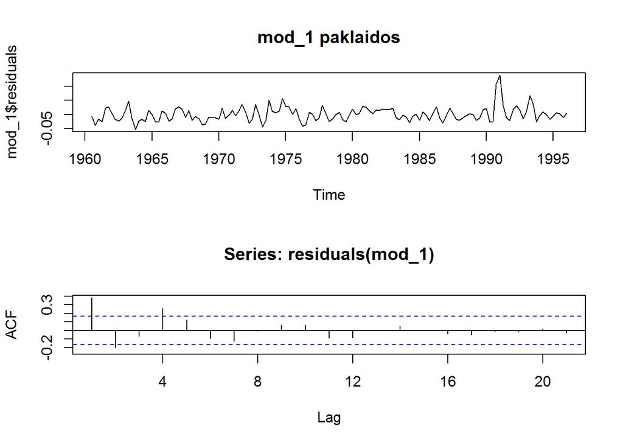

```r
par(mfcol=c(2,1))
plot(mod_1$residuals, main="mod_1 paklaidos")
Acf(residuals(mod_1))
```

```r
Box.test(residuals(mod_1), type="Ljung-Box")
```

```
##
##  Box-Ljung test
##
## data:  residuals(mod_1)
## X-squared = 21.603, df = 1, p-value = 3.353e-06
```

Toliau nebespėta

mod2:

```r
#par(mfcol=c(2,1))
#plot(mod2$residuals, main="mod2 paklaidos")
#Acf(residuals(mod2))
#Box.test(residuals(mod2), type="Ljung-Box")
```

mod3:

```r
#par(mfcol=c(2,1))
#plot(mod13$residuals, main="mod3 paklaidos")
#Acf(residuals(mod3))
#Box.test(residuals(mod3), type="Ljung-Box")
```

mod4:

```r
#par(mfcol=c(2,1))
#plot(mod4$residuals, main="mod1 paklaidos")
#Acf(residuals(mod4))
#Box.test(residuals(mod4), type="Ljung-Box")
```

2. `trainSet` ir `testSet`

```r
#length()*0.75 #Kiek duomenų trainSetui
#trainSet<-window(, end=c())
#testSet<-window(, start=c())
```

3. Moodeliai su trainSet

```r
#mod1_b<-ets(trainSet)
#mod2_b<-
#mod3_b<-auto.arima(trainSet)
#mod4_b<-
```

4. Prognozės:

```r
#f_mod1_b<-forecast(mod1_b, h=)
#plot(f_mod1_b)
#lines(testSet, col="red", lwd=2)

#f_mod2_b<-forecast(mod2_b, h=)
#plot(f_mod1_b)
#lines(testSet, col="red", lwd=2)

#f_mod3_b<-forecast(mod3_b, h=)
#plot(f_mod3_b)
#lines(testSet, col="red", lwd=2)

#f_mod4_b<-forecast(mod4_b, h=)
#plot(f_mod4_b)
#lines(testSet, col="red", lwd=2)
```

5. accuracy tikrinimas

```r
#tab1 = rbind(
#  accuracy(f_mod1_b, ser)[,2],
#  accuracy(f_mod2_b, ser)[,2],
#  accuracy(f_mod3_b, ser)[,2],
#  accuracy(f_mod4_b, ser)[,2]
#)
#rownames(tab1) <- c("f_mod1_b", "f_mod2_b", "f_mod3_b", "f_mod4_b")
#kable(tab1, digits=3)
```

```r
#modMain<-
```